# Homework 2 Solutions

Yi Liu

2018-09-09

```r
library(datasets)
library(ggplot2)
library(lattice)
library(latticeExtra)
library(factoextra)
library(tidyverse)
library(pscl)
library(DescTools)  # For model performance summary
```

## Question 1: Bias-Variance Tradeoff (25 points)

1a: Diagram

The diagram below illustrates the Bias-Variance Tradeoff. Different components of the diagram are labeled with the letters A through I. Fill in each of these labels with the name of the term or a short description.

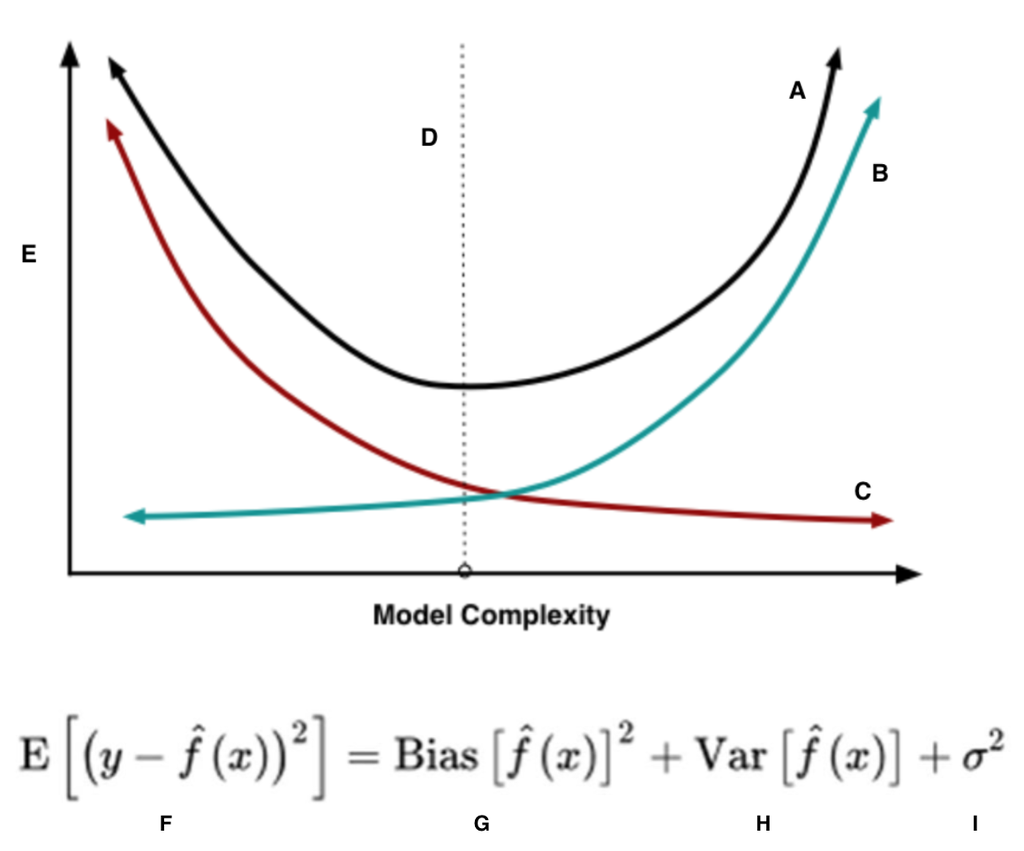

A = Total Error

B = Variance

C = Bias ^2

D = Optimum Model Complexity

E = Error

F = Mean Squared Error

G = Bias ^2

H = Variance

I = Irreducible Error

1b. **True or False:** Along the dotted line (D), the value of the curve (A) is equal to the sum of curves (B) and (C).

False. The statement doesn’t consider the irreducible error.

1c. **True or False.** The left side of the equation in Figure 1 (i.e., $E\left[(y − \hat{f}(x))^2\right]$ will never be negative.

True. It will never be negative.

1d. **True or False.** In general, we expect $Var(\hat{f}(x))$ in the equation to be smaller when we use more flexible methods.

False. As we use more felxible methods, the model will fit the dataset better with low bias, and variance will be high.

1e. **True or False.** As we move from less flexible to more flexible methods, $[bias(\hat{f}(x))]^2$ will usually not increase.

True. With more felxible methods, model will fit the dataset better, so bias will usually not increase.

1f. **True or False.** More data will reduce the bias of an estimator.

True. More data generally reduces bias of an estimator as it represents more information about the true process. Mathematically, bias is a component of MSE, which is divided by n observations, and thus tends to decrease with increasing observations.

1g. **True or False.** More data will reduce the variance of an estimator.

True. With more data, the result would be more consistent each time we run the model, making the variance closer to the true average level, so the variance of an estimator will be reduced.

## Question 2: KMEAN Clustering Problem (25 points)

We will cluster the *iris* dataset to understand the structure of dataset via the already designed function so-called *kmeans()*. We also will design a program to visually determine the number of clusters.

2a. After loading the *iris* dataset, retrieve the numerical measures and standardize the iris dataset. Explain how the standard deviation of variables changes.

```r
data("iris")
# Retrieve the numerical measures and standardize
library(dplyr)
newiris <- dplyr::select_if(iris, is.numeric)
iris_s <- as.data.frame(apply(newiris, 2, function(x) (x -
    mean(x))/sd(x)))
# Use datatable to show the change of the standard
# deviation
library("DT")
sd_original <- apply(newiris, 2, sd)
sd_scaled <- apply(iris_s, 2, sd)
colt <- cbind(sd_original, sd_scaled)
tog <- datatable(colt)
show(tog)
```

*After standardizing, iris data has been transformed so that standard deviation equal to 1 now for all four variables*

2b. Visualize the width and length measurements separately. Did you find any correlations?

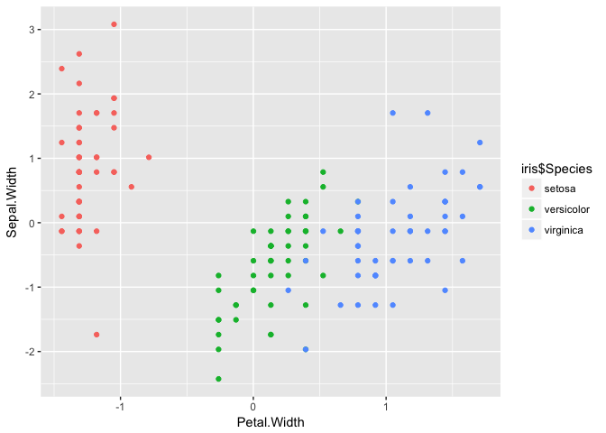

```r
# Draw the petal width vs sepal width
ggplot(data = iris_s, aes(x = Petal.Width, y = Sepal.Width)) +
    geom_point(aes(color = iris$Species))
```

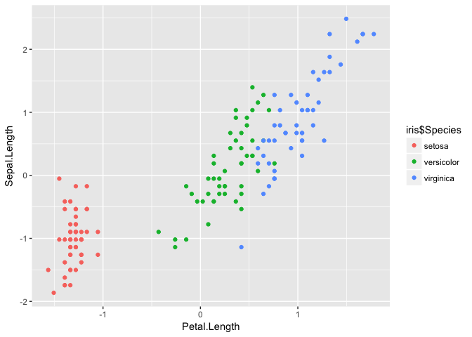

```r
# Draw the petal length vs the sepal length
ggplot(data = iris_s, aes(x = Petal.Length, y = Sepal.Length)) +
    geom_point(aes(color = iris$Species))
```

2c. Construct the K-means algorithm using *kmeans()* function on the whole dataset with the *k* value of 3.

```r
# K-means algorithm
set.seed(101)
result <- kmeans(iris_s, centers = 3, nstart = 25)  # apply k-means algorithm with k=3
result$size  # gives no. of records in each cluster
```

```
[1] 53 50 47
```

```r
result$centers  # gives value of cluster center datapoint value (3 centers for k=3)
```

```
  Sepal.Length Sepal.Width Petal.Length Petal.Width
1  -0.05005221 -0.88042696    0.3465767   0.2805873
2  -1.01119138  0.85041372   -1.3006301  -1.2507035
3   1.13217737  0.08812645    0.9928284   1.0141287
```

```r
result$cluster  # gives cluster vector showing the custer where each record falls
```

```
  [1] 2 2 2 2 2 2 2 2 2 2 2 2 2 2 2 2 2 2 2 2 2 2 2 2 2 2 2 2 2 2 2 2 2 2 2
 [36] 2 2 2 2 2 2 2 2 2 2 2 2 2 2 2 3 3 3 1 1 1 3 1 1 1 1 1 1 1 1 3 1 1 1 1
 [71] 3 1 1 1 1 3 3 3 1 1 1 1 1 1 1 3 3 1 1 1 1 1 1 1 1 1 1 1 1 1 3 1 3 3 3
[106] 3 1 3 3 3 3 3 3 1 1 3 3 3 3 1 3 1 3 1 3 3 1 3 3 3 3 3 3 1 1 3 3 3 1 3
[141] 3 3 1 3 3 3 1 3 3 1
```

```r
str(result)
```

```
List of 9
 $ cluster     : int [1:150] 2 2 2 2 2 2 2 2 2 2 ...
 $ centers     : num [1:3, 1:4] -0.0501 -1.0112 1.1322 -0.8804 0.8504 ...
  ..- attr(*, "dimnames")=List of 2
  .. ..$ : chr [1:3] "1" "2" "3"
  .. ..$ : chr [1:4] "Sepal.Length" "Sepal.Width" "Petal.Length" "Petal.Width"
 $ totss       : num 596
 $ withinss    : num [1:3] 44.1 47.4 47.5
 $ tot.withinss: num 139
 $ betweenss   : num 457
 $ size        : int [1:3] 53 50 47
 $ iter        : int 2
 $ ifault      : int 0
 - attr(*, "class")= chr "kmeans"
```

2d. Inspect the output:

1. Calculate the total within-cluster variance.

```r
result
```

```
K-means clustering with 3 clusters of sizes 53, 50, 47

Cluster means:
  Sepal.Length Sepal.Width Petal.Length Petal.Width
1  -0.05005221 -0.88042696    0.3465767   0.2805873
2  -1.01119138  0.85041372   -1.3006301  -1.2507035
3   1.13217737  0.08812645    0.9928284   1.0141287

Clustering vector:
  [1] 2 2 2 2 2 2 2 2 2 2 2 2 2 2 2 2 2 2 2 2 2 2 2 2 2 2 2 2 2 2 2 2 2 2 2
 [36] 2 2 2 2 2 2 2 2 2 2 2 2 2 2 2 3 3 3 1 1 1 3 1 1 1 1 1 1 1 1 3 1 1 1 1
 [71] 3 1 1 1 1 3 3 3 1 1 1 1 1 1 1 3 3 1 1 1 1 1 1 1 1 1 1 1 1 1 3 1 3 3 3
[106] 3 1 3 3 3 3 3 3 1 1 3 3 3 3 1 3 1 3 1 3 3 1 3 3 3 3 3 3 1 1 3 3 3 1 3
[141] 3 3 1 3 3 3 1 3 3 1

Within cluster sum of squares by cluster:
[1] 44.08754 47.35062 47.45019
 (between_SS / total_SS =  76.7 %)

Available components:

[1] "cluster"      "centers"      "totss"        "withinss"
[5] "tot.withinss" "betweenss"    "size"         "iter"
[9] "ifault"
```

```r
# total within-cluster variance calculation
result$tot.withinss
```

```
[1] 138.8884
```

*Total within-cluster variance from K-means clustering with 3 clusters of sizes 53, 50, 47 result is 138.8884*

2. Visualize the results against the truth.

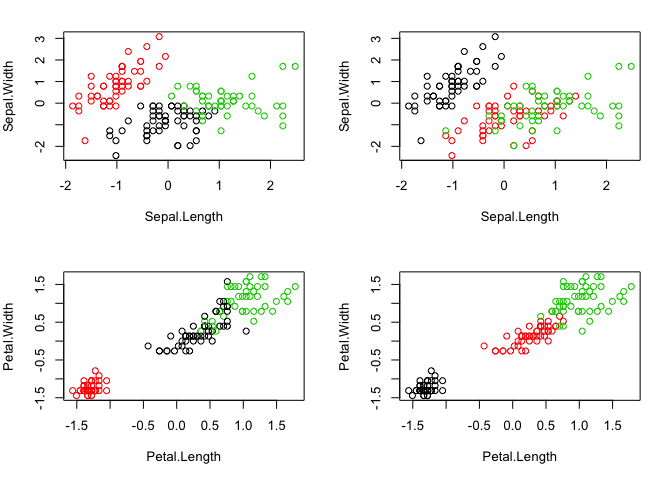

```r
iris.class <- iris[, "Species"]
par(mfrow = c(2, 2), mar = c(5, 4, 2, 2))
plot(iris_s[c(1, 2)], col = result$cluster)  # Plot to see how Sepal.Length and Sepal.Width data points have been distributed in clusters
plot(iris_s[c(1, 2)], col = iris.class)  # Plot to see how Sepal.Length and Sepal.Width data points have been distributed originally as per 'class' attribute in dataset
plot(iris_s[c(3, 4)], col = result$cluster)  # Plot to see how Petal.Length and Petal.Width data points have been distributed in clusters
plot(iris_s[c(3, 4)], col = iris.class)
```

iii). Plot the cluster centers over the data for both width and length.

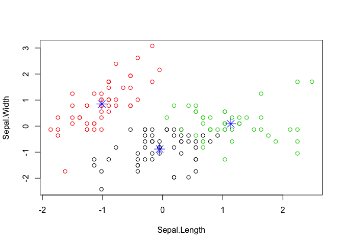

```r
# Sepal width and length plot with cluser centers
plot(iris_s[c(1, 2)], col = result$cluster)
points(result$centers[, 1:2], col = "blue", pch = 8, cex = 2)
```

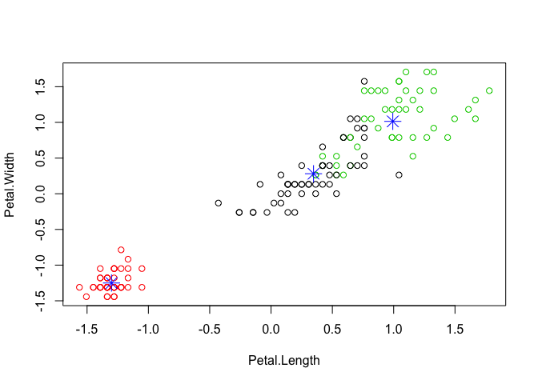

```r
# Petal width and length plot with cluser centers
plot(iris_s[c(3, 4)], col = result$cluster)
points(result$centers[, 3:4], col = "blue", pch = 8, cex = 2)
```

2e. Program a code to plot the scree plot (via “elbow” method; sum of within-cluster variance vs. *k* value). Determine the plausible number of clusters and explain your reasons.

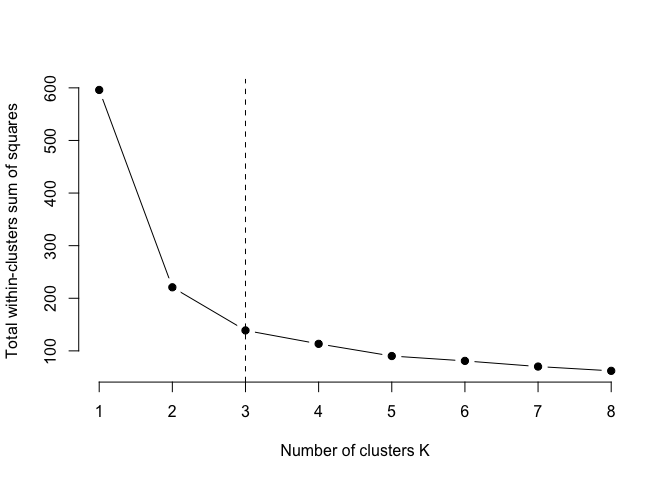

```r
set.seed(139)
# Build function to compute total within-cluster sum of
# square
wcss <- function(k) {
    kmeans(iris_s, k, nstart = 25)$tot.withinss
}

# Compute and plot wss for k = 1 to 8
k_values <- 1:8

# Extract wss for 2-7 clusters
wss_values <- map_dbl(k_values, wcss)

plot(k_values, wss_values, type = "b", pch = 19, frame = FALSE,
    xlab = "Number of clusters K", ylab = "Total within-clusters sum of squares")
abline(v = 3, lty = 2)
```

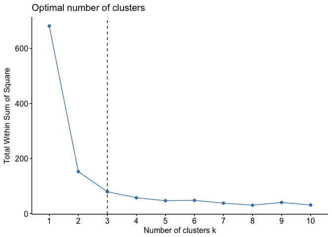

```r
fviz_nbclust(newiris, kmeans, method = c("wss")) + geom_vline(xintercept = 3,
    linetype = 2)
```

*I find that 3 clusters are optimal using this method, since the location of a bend (knee) in the plot is generally considered as an indicator of the appropriate number of clusters*

## Question 3: Hierarchy Clustering Problem (25 points)

The *nutrient* dataset contains the measurements of nutrients in several types of meat, fish, and fowl. We can characterize the nutrients of types of food. In this practice, we are going to group the food by the common nutrient characteristics than the type of food using the Hierarchy Clustering method, *hclust()* and *cutree()* functions.

3a. Load the **flexclust** library and the *nutrient* dataset.

```r
library(flexclust)
data("nutrient")
head(nutrient)
```

```
                energy protein fat calcium iron
BEEF BRAISED       340      20  28       9  2.6
HAMBURGER          245      21  17       9  2.7
BEEF ROAST         420      15  39       7  2.0
BEEF STEAK         375      19  32       9  2.6
BEEF CANNED        180      22  10      17  3.7
CHICKEN BROILED    115      20   3       8  1.4
```

3b. Scale the data and calculate the pairwise distances between observations. Explain why we need to scale the data.

```r
newnutri <- scale(nutrient)  # Scale the data
d <- dist(newnutri, method = "euclidean")
print(d)  # The pairwise distances between observations
```

```
                    BEEF BRAISED  HAMBURGER BEEF ROAST BEEF STEAK
HAMBURGER             1.37693318
BEEF ROAST            1.76971526 3.00514082
BEEF STEAK            0.54879378 1.91086906 1.28012553
BEEF CANNED           2.41960469 1.15467556 4.04232701 2.93372154
CHICKEN BROILED       3.24792236 2.01084828 4.56735495 3.73712184
CHICKEN CANNED        2.87273686 1.70270898 4.45371386 3.40506963
BEEF HEART            3.79907517 2.83268851 5.43566380 4.25206933
LAMB LEG ROAST        1.02674329 0.41240192 2.59740322 1.54044405
LAMB SHOULDER ROAST   0.70046358 1.17182323 1.86901537 1.01651211
SMOKED HAM            0.06843197 1.38202525 1.75510108 0.55304390
PORK ROAST            0.26056371 1.50248216 1.55460246 0.44192630
PORK SIMMERED         0.35718696 1.66684008 1.41857913 0.29891166
BEEF TONGUE           1.88483004 0.86283670 3.17173103 2.33214378
VEAL CUTLET           2.38680488 1.03816317 4.03289606 2.93064368
BLUEFISH BAKED        3.28400837 2.16274520 4.61285301 3.77137351
CLAMS RAW             4.86202685 4.06408614 5.71454639 5.14727391
CLAMS CANNED          5.28800776 4.56897528 5.90043040 5.52688380
CRABMEAT CANNED       3.88370297 2.94284632 4.72465729 4.25092672
HADDOCK FRIED         3.35164411 2.44398850 4.26282737 3.73431450
MACKEREL BROILED      2.22392292 1.37885086 3.37842982 2.65331534
MACKEREL CANNED       3.31240087 2.57977308 4.21036174 3.64614644
PERCH FRIED           2.45231513 1.68318068 3.37965229 2.81719989
SALMON CANNED         3.84487859 3.01911322 4.76610424 4.20806666
SARDINES CANNED       5.15957958 4.69455330 6.06929645 5.42555321
TUNA CANNED           2.93308985 1.81044593 4.47371166 3.45613920
SHRIMP CANNED         3.56594536 2.30785746 5.08390171 4.07742476
                    BEEF CANNED CHICKEN BROILED CHICKEN CANNED BEEF HEART
HAMBURGER
BEEF ROAST
BEEF STEAK
BEEF CANNED
CHICKEN BROILED      1.87376728
CHICKEN CANNED       1.68798793      1.34605872
BEEF HEART           1.84104857      3.42193002     3.02712169
LAMB LEG ROAST       1.51423799      2.26974204     2.04103410 3.15391985
LAMB SHOULDER ROAST  2.23491927      2.78594305     2.68673226 3.83192619
SMOKED HAM           2.44176050      3.23129884     2.85556920 3.84014697
PORK ROAST           2.55553724      3.30137409     3.01697112 3.97954418
PORK SIMMERED        2.72876990      3.44962652     3.14453758 4.13469777
```

[output cut: 134 more lines]

```
PORK SIMMERED
BEEF TONGUE
VEAL CUTLET
BLUEFISH BAKED
CLAMS RAW
CLAMS CANNED
CRABMEAT CANNED
HADDOCK FRIED
MACKEREL BROILED
MACKEREL CANNED
PERCH FRIED
SALMON CANNED        2.12365271
SARDINES CANNED      4.81485341    3.23772139
TUNA CANNED          2.16352949    2.77980242      4.75538586
SHRIMP CANNED        2.48098659    2.10454763      3.59536370  1.77047909
```

```r
head(nutrient)
```

```
                energy protein fat calcium iron
BEEF BRAISED       340      20  28       9  2.6
HAMBURGER          245      21  17       9  2.7
BEEF ROAST         420      15  39       7  2.0
BEEF STEAK         375      19  32       9  2.6
BEEF CANNED        180      22  10      17  3.7
CHICKEN BROILED    115      20   3       8  1.4
```

*We need to scale the data in order to standardize the variables. For example, the scale of energy, protein, fat, calcium and iron are different, for having better understanding of proportion of between variables, it is better to scale data.*

3c. Create various dendrograms using **single**, **complete**, and **average** linkage.

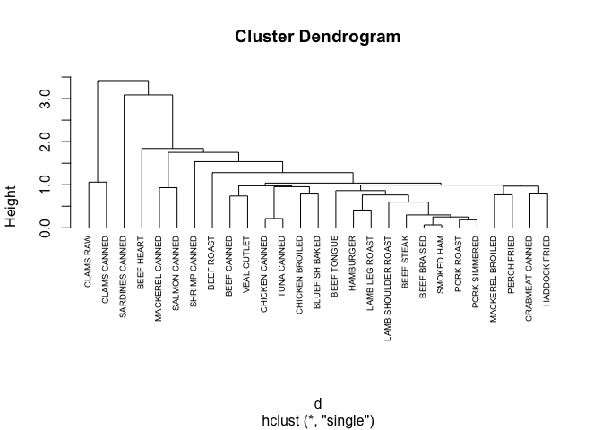

```r
# Single-linkage clustering of the nutrient data
hc1 <- hclust(d, method = "single")
plot(hc1, cex = 0.6, hang = -1)
```

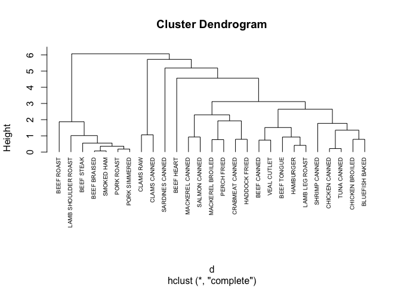

```r
# Complete-linkage clustering of the nutrient data
hc2 <- hclust(d, method = "complete")
plot(hc2, cex = 0.6, hang = -1)
```

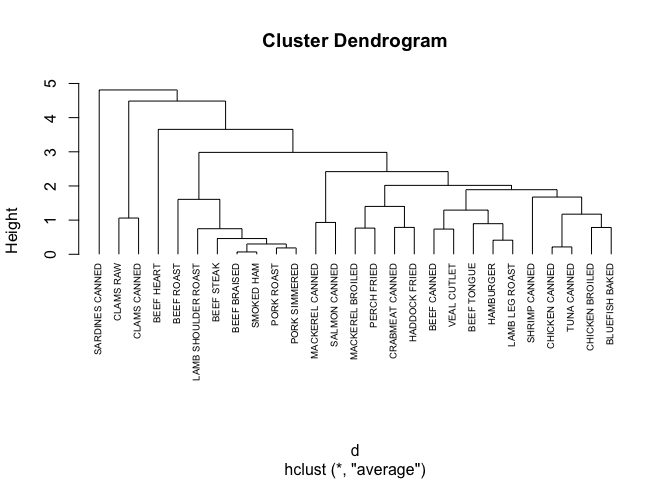

```r
# Average-linkage clustering of the nutrient data
hc3 <- hclust(d, method = "average")
plot(hc3, cex = 0.6, hang = -1)
```

3d. Cut the dendrogram into groups of 5.

```r
# Single linkage
grp1 <- cutree(hc1, k = 5)
# Complete linkage
grp2 <- cutree(hc2, k = 5)
# Average linkage
grp3 <- cutree(hc3, k = 5)
```

3e. Aggregate the original and scaled data by the cluster assignments. Discuss the results.

```r
# Describes clusters by single linkage method
sing <- aggregate(newnutri, by = list(cluster = grp1), median)
sing
```

```
  cluster      energy    protein         fat    calcium        iron
1       1 -0.07319008  0.2352002 -0.04277161 -0.4480464  0.01267259
2       2 -0.46841651  1.6464016 -0.75343843 -0.3839719  2.40779157
3       3 -1.48118425 -2.3520023 -1.10877184  0.4361807  2.27092763
4       4 -0.69073138 -0.5880006 -0.57577173  1.4613715 -0.77429508
5       5 -0.27080330  0.7056007 -0.39810502  4.1396825  0.08110456
```

```r
# Describes clusters by complete linkage method
comp <- aggregate(newnutri, by = list(cluster = grp2), median)
comp
```

```
  cluster     energy    protein        fat    calcium        iron
1       1  1.3101024  0.0000000  1.3785620 -0.4480464  0.08110456
2       2 -0.3696099  0.2352002 -0.4869384 -0.3967868 -0.63743114
3       3 -0.4684165  1.6464016 -0.7534384 -0.3839719  2.40779157
4       4 -1.4811842 -2.3520023 -1.1087718  0.4361807  2.27092763
5       5 -0.2708033  0.7056007 -0.3981050  4.1396825  0.08110456
```

```r
# Describes clusters by average linkage method
aver <- aggregate(newnutri, by = list(cluster = grp3), median)
aver
```

```
  cluster     energy    protein        fat    calcium        iron
1       1  1.3101024  0.0000000  1.3785620 -0.4480464  0.08110456
2       2 -0.3696099  0.2352002 -0.4869384 -0.3967868 -0.63743114
3       3 -0.4684165  1.6464016 -0.7534384 -0.3839719  2.40779157
4       4 -1.4811842 -2.3520023 -1.1087718  0.4361807  2.27092763
5       5 -0.2708033  0.7056007 -0.3981050  4.1396825  0.08110456
```

*The results show that different methods in hierarchical clustering generate 5 different groups. The group median of complete and average methods are the same. With scaled data and their median, we could have better understanding of the composition of those nutrition variables.*

3f. Visualize the groups in the dendrogram.

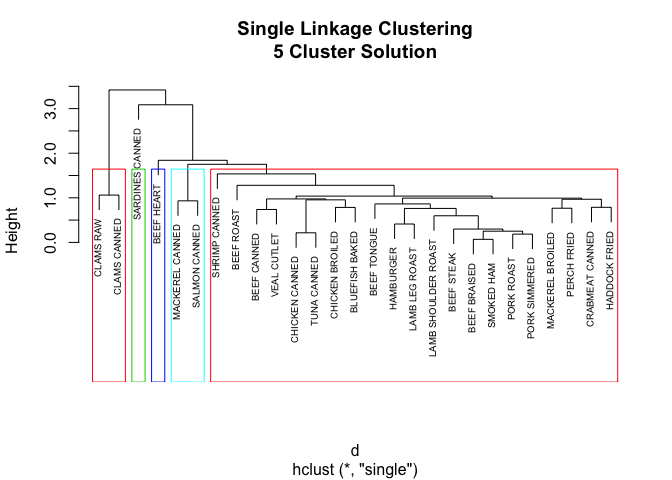

```r
plot(hc1, cex = 0.6, main = "Single Linkage Clustering\n5 Cluster Solution")
rect.hclust(hc1, k = 5, border = 2:5)
```

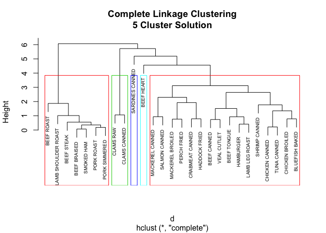

```r
plot(hc2, cex = 0.6, main = "Complete Linkage Clustering\n5 Cluster Solution")
rect.hclust(hc2, k = 5, border = 2:5)
```

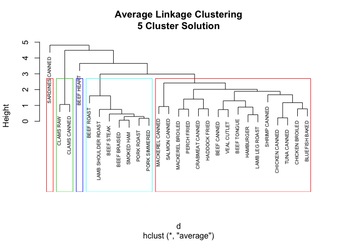

```r
plot(hc3, cex = 0.6, main = "Average Linkage Clustering\n5 Cluster Solution")
rect.hclust(hc3, k = 5, border = 2:5)
```

3g. Discuss the common nutrient characteristics in each group. *Among three methods, Beef heart/Sardnies canned/Clams raw and clams canned are always singleton. Take average linkage clustering for example: Beef heart is high in protein and iron. Sardnies canned has much higher in calcium than the other food groups. The clam cluster(clams raw and clams canned) is low in protein and high in iron. The group (beef roast to pork simmered) are high in energy and fat compared to other groups. The largest group (mackerel to bluefish) is relatively low in iron.*